# Introduction to Data Manipulation and Visualization in R

Francesca Giannetti

## Introduction to Data Manipulation and Visualization in R

[figure not shown]

#MLATechCamp, January 31, 2018

Francesca Giannetti  
Digital Humanities Librarian  
Rutgers University–New Brunswick  
francescagiannetti.com | @jo_frankie

## Overview

1. Visualization in R
2. Precursors to visualization
   - Data collection
   - Data cleaning and manipulation (tidy data)
3. Hands-on worksheet

## Accessing RStudio Server

- Go to the URL that I’ll give in person at the workshop (the URL on the slips is wrong. Whoops!).
- Enter your username and password from the slip. An Rstudio instance will open in your browser.

## Download Workshop Materials

- In a second browser tab, go to http://bit.ly/MLATechR and download today’s workshop materials (click on green “Clone or download” button and select “Download ZIP”).
- Back in Rstudio, click on the “Upload” button of the lower right pane and upload the zipped `mlatechcamp-master.zip` file. Click to enter the new `mlatechcamp-master` folder in your Rstudio Files pane.
- To open this presentation, click on `01-presentation.Rmd`.

## One more thing

If you are following along in the presentation Rmarkdown file, be sure to run this little code chunk to load the tidyverse library. We’ll need it for the examples to work.

```r
# load tidyverse package
library(tidyverse)
```

## Why program at all?

1. You understand more deeply what computers do to your data. By understanding the workings of an algorithm, you can better justify your claims as well as understand the ways algorithms may distort the data.
2. The work of data analysis becomes transparent. Since we’re writing code, we can trace the steps we made to make something.
3. We start to correct for the problem of tools shaping research questions. In other words, we build the tool to fit our questions.

Thanks to [J. Heppler and L. Mullen](https://github.com/hepplerj/dhsi2016-visualization) for the wording.

## Why R?

1. Lots of libraries (ways of extending R language).
2. The language is designed for data analysis.
3. R has a set of tools available that makes writing code easier.
4. Lots of humanists use R.
5. Reproducibility.

## Tidyverse

`tidyverse` is a set of packages for data tidying, manipulation, and visualization. We’ll look specifically at `dplyr` (manipulation) and `ggplot2` (visualization) today. Their creator, Hadley Wickham, introduced the innovation of a human-friendly (at least for Westerners), left-to-right syntax. With `ggplot`, Wickham adapted Leland Wilkinson’s *Grammar of Graphics* (1999) for the modular construction of graphs.

More on `tidyverse`? *See* Grolemund, Garrett, and Hadley Wickham. *R for Data Science*. Sebastopol, CA: O’Reilly Media, 2017. http://r4ds.had.co.nz/.

## Example: Oregon Population

```r
# install.packages("historydata")
library(historydata)
data(us_state_populations)

# Let's look at just Oregon
oregon <- us_state_populations %>% filter(state == 'Oregon') %>% select(-GISJOIN)
oregon
```

```
## # A tibble: 16 x 3
##     year state  population
##    <int> <chr>       <int>
##  1  1860 Oregon      52465
##  2  1870 Oregon      90923
##  3  1880 Oregon     174768
##  4  1890 Oregon     313767
##  5  1900 Oregon     413536
##  6  1910 Oregon     672765
##  7  1920 Oregon     783389
##  8  1930 Oregon     953786
##  9  1940 Oregon    1089684
## 10  1950 Oregon    1521341
## 11  1960 Oregon    1768687
## 12  1970 Oregon    2091385
## 13  1980 Oregon    2633105
## 14  1990 Oregon    2842321
## 15  2000 Oregon    3421399
## 16  2010 Oregon    3831074
```

## Tidy Data

Tidy data, according to Wickham, features:

- Variables in columns
- Observations in rows
- Each table corresponds to a type of observational unit

Tidy data is easier to manipulate and visualize, allowing you to focus on the interesting questions, as opposed to the less interesting logistics of data.

Wickham, Hadley. “Tidy Data.” *Journal of Statistical Software* 59, no. 10 (September 12, 2014): 1–23. http://dx.doi.org/10.18637/jss.v059.i10.

## Tidy or not?

| state | 1790 | 1800 | 1810 | 1820 | 1830 | 1840 |
| --- | --- | --- | --- | --- | --- | --- |
| Virginia | 1 | 2 | 3 | 4 | 5 | 6 |
| Massachusetts | 7 | 8 | 9 | 10 | 11 | 12 |
| New York | 13 | 14 | 15 | 16 | 17 | 18 |
| Connecticut | 19 | 20 | 21 | 22 | 23 | 24 |

## Tidy or not?

| state | year | population |
| --- | --- | --- |
| Virginia | 1790 | 1 |
| Massachusetts | 1790 | 7 |
| New York | 1790 | 13 |
| Connecticut | 1790 | 19 |
| Virginia | 1800 | 2 |
| Massachusetts | 1800 | 8 |
| New York | 1800 | 14 |
| Connecticut | 1800 | 20 |

Thanks to [J. Heppler](https://github.com/unolibraries/workshops) for the examples.

## Plotting Population Data

An unsurprising plot.

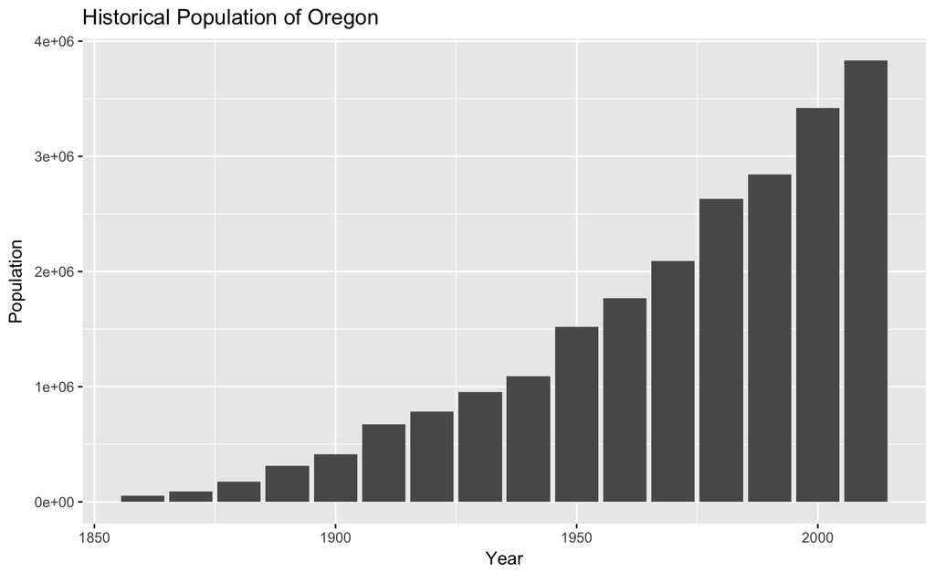

## The Grammar of Graphics

```r
ggplot(data = oregon, aes(x = year, y = population)) +
  geom_bar(stat="identity")
```

## Semantic Components

Let’s break that code down line-by-line.

```r
ggplot(data = oregon, aes(x = year, y = population)) +
  geom_bar(stat="identity")
```

`ggplot()` needs:

1. mapping of **data**
2. to **aesthetic attributes**
3. using **geometric objects**
4. with data **statistically transformed**
5. and, if needed, mapped onto a **facet** or **coordinate system**

## Semantic Components (2)

**data**: data as an R data frame

**geoms**: describe the geometric objects that represent data, such as points, lines, and polygons.

**aesthetics**: describe visual characteristics that represent data, such as position, size, color, and shape.

**stats**: describe statistical transformations such as counts, means, medians, or regression lines.

## ggplot() Function Call

Let’s review what we did with the `ggplot()` code. The code for our previous bar chart looked like:

```r
ggplot(data = oregon, aes(x = year, y = population)) +
  geom_bar(stat="identity")
```

### Mapping of **data**:

```r
data = oregon
```

### to **aesthetic attributes**:

```r
aes(x = year, y = population)
```

### using **geometric objects**:

```r
geom_bar(stat="identity")
```

## ggplot() Function Call (2)

See the [geom_bar documentation](http://docs.ggplot2.org/current/geom_bar.html) for the differences in the `stat` flag. By default, `geom_bar` uses `stat='count'` which sets the height of the bar proportion to the number of cases in each group. Since we want the height of the bars to represent values in the data, we use `stat='identity'` to map a variable to the `y` aesthetic.

## Scatterplot

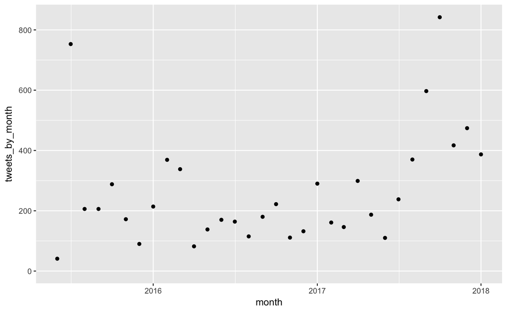

## Line plot

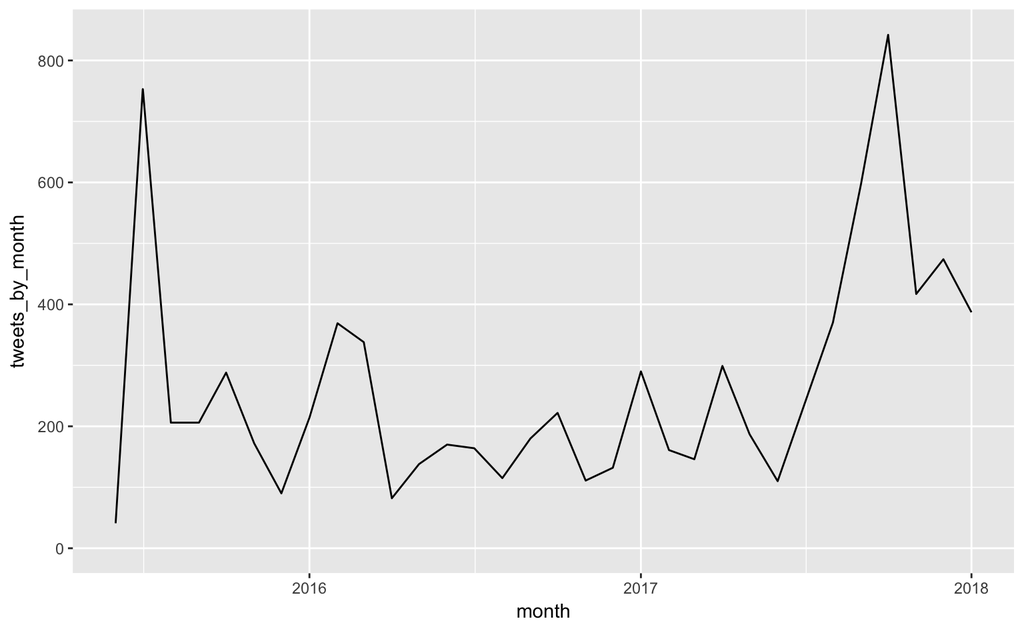

## Smoothing

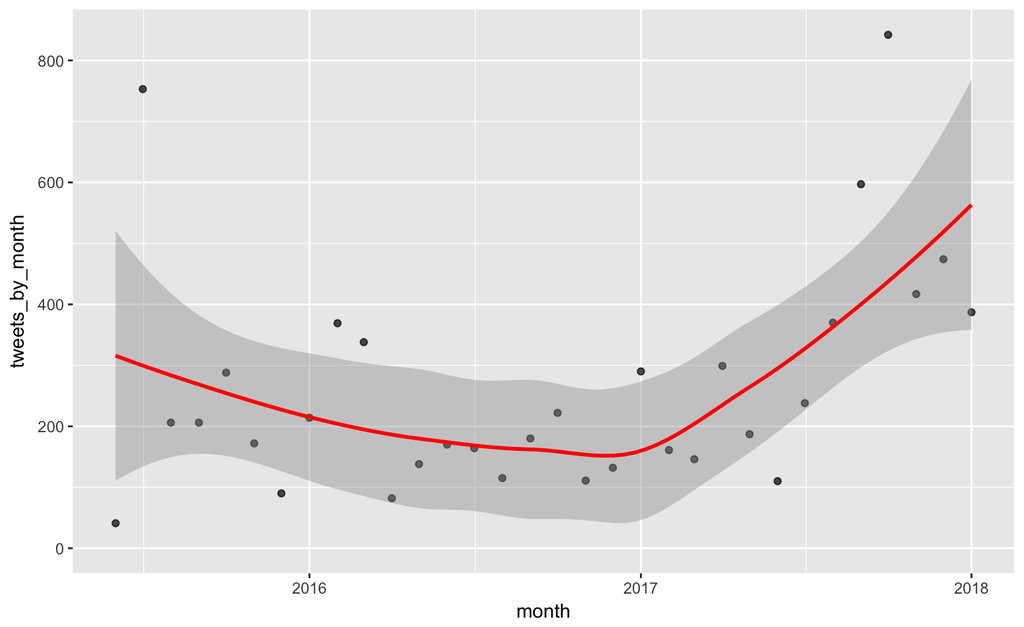

## Et cetera

Although we only have time for `dplyr` and `ggplot2` today, I would be remiss if I didn’t touch upon the other types of visualization possible in R.

## Networks

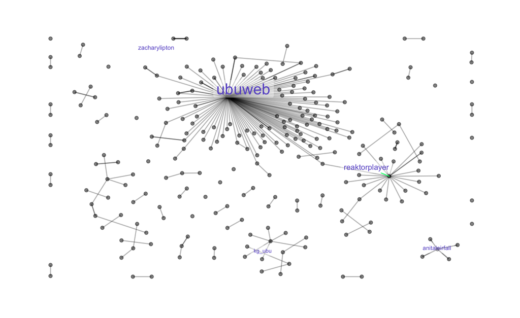

## Maps

[interactive chart not shown]

## Web Graphics

With [`htmlwidgets`](http://www.htmlwidgets.org/index.html) and [`shiny`](https://shiny.rstudio.com/), it is also possible to create interactive visualizations and host them on the web. `htmlwidgets` creates R bindings for some well-known JavaScript libraries, like sigma.js and networkD3.

## Resources

I find the [R Graph Catalog](http://shiny.stat.ubc.ca/r-graph-catalog) to be particularly helpful when deciding which kind of graph is appropriate for my data. The site is a realization in the R language of the lessons presented in Robbins, Naomi R. *Creating More Effective Graphs*. Wayne, NJ: Chart House, 2013.

While there are countless books on coding in R, I find myself returning to these resources again and again: Jenny Bryan’s [stat545](http://stat545.com/index.html) class and Jason Heppler’s and Lincoln Mullen’s class on [R and Data Visualization in the Humanities](https://github.com/hepplerj/dhsi2016-visualization).

## Worksheet

Back to the beginning. Let’s take a look at the worksheet for `dplyr` and `ggplot2`.